# waferscopeR User Guide

2017-02-20

R package for wafer level statistics and lot analysis. You can install package from github:

```r
devtools::install_github("drmanager/waferscopeR")
```

This guide is to demonstrate the functions of **waferscopeR** and document the internal data sets for exploration.

- Functions to read from raw data files
- Wafer level statistics
- Plot and compare wafer maps
- Explore wafer lot data

## Read Raw Data Files

The function **read_kla_f5** reads the raw data file output from KLA-Tencor Spectra Ellipsometry tool directly. The data is saved in a list, which can be accessed by slot number. The dataset “lot1” contain one lot (25 wafers) native oxide measured on Silicon substrate.

```r
library(waferscopeR)
native_oxide <- system.file("extdata", "native_oxide.csv", package="waferscopeR")
lot1 <- read_kla_f5(native_oxide)
```

Each wafer cab be accessed by index within the list or slot number such as “slot1”. The data structure contains layer thickness, good of fit (GOF) and (x,y) coordinates of measurement within a wafer.

```r
#Wafer names in the list
names(lot1)
```

```
##  [1] "slot1"  "slot2"  "slot3"  "slot4"  "slot5"  "slot6"  "slot7"
##  [8] "slot8"  "slot9"  "slot10" "slot11" "slot12" "slot13" "slot14"
## [15] "slot15" "slot16" "slot17" "slot18" "slot19" "slot20" "slot21"
## [22] "slot22" "slot23" "slot24" "slot25"
```

```r
#Retrieve by wafer index and return as dataframe
head(lot1[[1]])
```

```
##    1st Thickness  GOF         X        Y
## 32          9.51 0.992   0.0000   0.0000
## 33          9.53 0.991  -0.0001  49.0000
## 34          9.55 0.992 -34.6483  34.6480
## 35          9.63 0.991 -49.0000  -0.0001
## 36          9.71 0.991 -34.6480 -34.6483
## 37          9.68 0.992   0.0001 -49.0000
```

```r
#Retrieve by slot name and return as dataframe
head(lot1[["slot1"]])
```

```
##    1st Thickness  GOF         X        Y
## 32          9.51 0.992   0.0000   0.0000
## 33          9.53 0.991  -0.0001  49.0000
## 34          9.55 0.992 -34.6483  34.6480
## 35          9.63 0.991 -49.0000  -0.0001
## 36          9.71 0.991 -34.6480 -34.6483
## 37          9.68 0.992   0.0001 -49.0000
```

## Wafer Statistics

wafer_stat function would take wafer coordinate and thickness data and return list of statistics.

- Mean thickness (mean.stat), 3 sigma, range and their 3-sigma and range NU in percentage
- Radial component of the map (radial.stat), 3 sigma and range
- Residual component of the map (resi.stat), 3 sigma and range

```r
#read slot1 from collection and change the col name of "1st Thickness" to "ThK"
wafer.slot1 <-lot1[["slot1"]]
colnames(wafer.slot1) <- c("ThK","GOF","X","Y")

# Output the statis of wafer
wafer_stat(wafer = wafer.slot1)
```

```
## $mean.stat
## [1] "Mean: 9.8A 3-sigma: 0.7A (7.1%) Range: 1.2A (12.2%)"
##
## $radial.stat
## [1] "3-sigma: 0.5A (5.1%) Range: 0.5A (5.1%)"
##
## $resi.stat
## [1] "3-sigma: 0.6A Range: 1A "
```

## Wafer Map

Contour maps are used to visualize the data distribution across the wafers. Options to control the map output:

- point = “on” shows data on the map, point = “off” turn-off data in the map

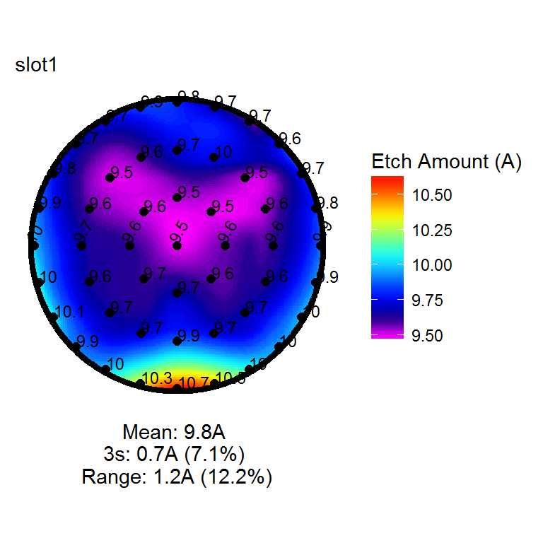

```r
wafer.slot1 <-lot1[["slot1"]]
colnames(wafer.slot1) <- c("ThK","GOF","X","Y")

#Visualize mean map with datapoints on
map_wafer(wafer=wafer.slot1,resolution="normal",point="on",maps="mean", wlabel = "slot1")
```

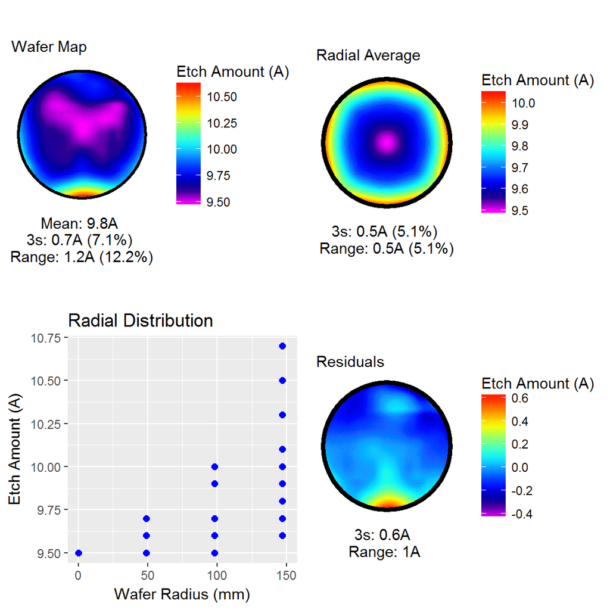

```r
wafer.slot1 <-lot1[["slot1"]]
colnames(wafer.slot1) <- c("ThK","GOF","X","Y")


#Visualize mean map, radial, residual and radial distribution maps
map_wafer(wafer=wafer.slot1,resolution="normal",point="off",maps="all")
```

- maps = “decompose” all the radial and residual maps: a good way to visualize symmetric vs asymmetric components

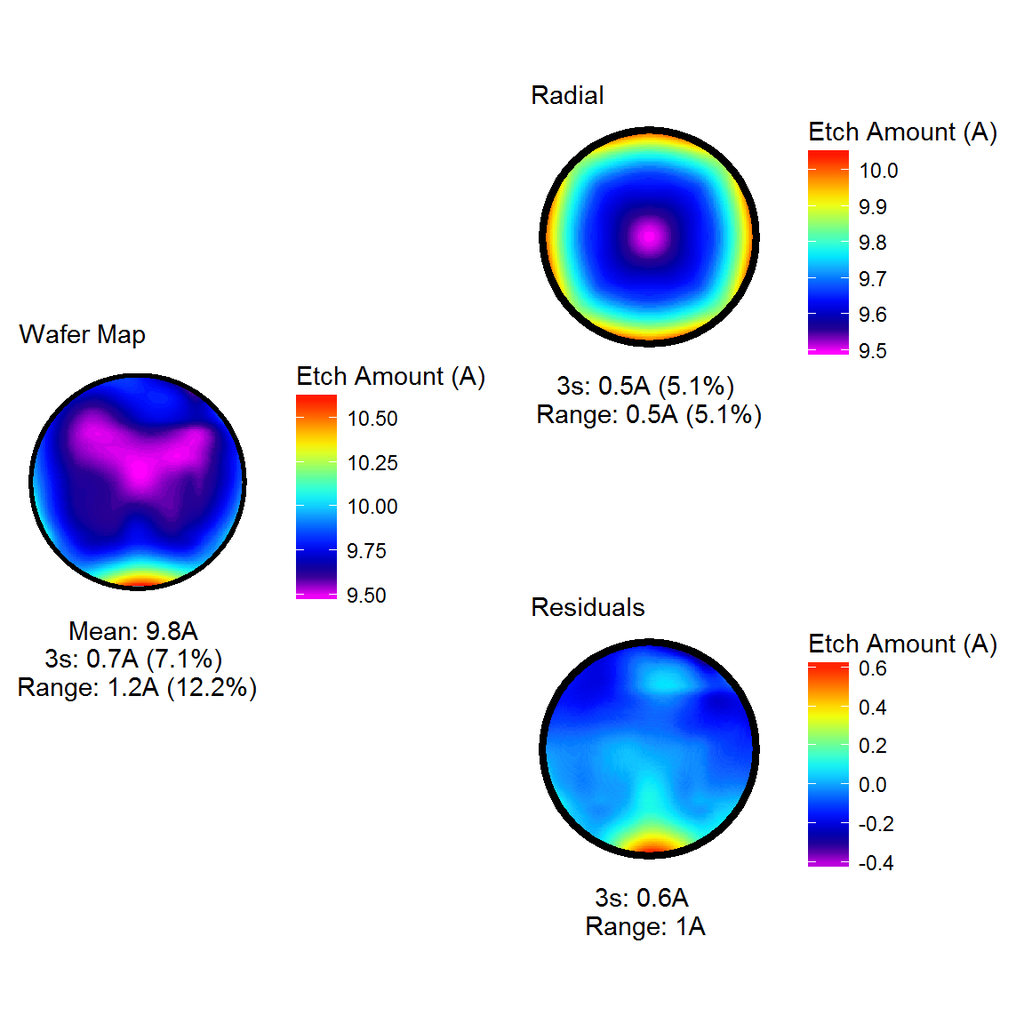

```r
wafer.slot1 <-lot1[["slot1"]]
colnames(wafer.slot1) <- c("ThK","GOF","X","Y")


#decompose into different points
map_decompose(wafer=wafer.slot1,resolution="normal",point="off",maps="decompose")
```

## Explore wafer lot

A quick exploration of wafer maps can be done with KLA raw data files. explore_lot_klaraw(pre,post) takes in pre and post files and output the pre, post and delta thickness and a table with uniformity statistics.

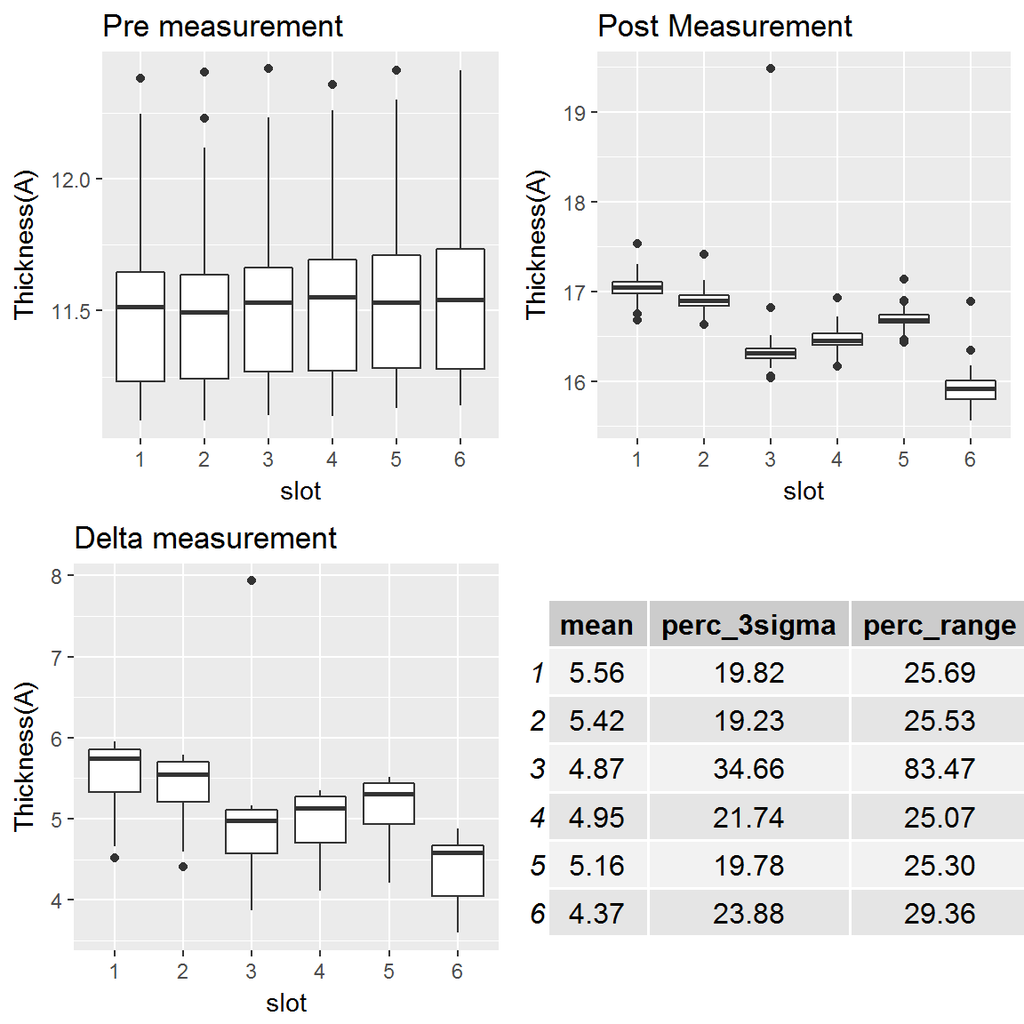

```r
pre <- system.file("extdata", "pre.csv", package="waferscopeR")
post <- system.file("extdata", "post.csv", package="waferscopeR")

explore_lot_klaraw(pre,post)
```

Explore the data with a single file with explore_klaraw (file, output)

```r
explore_klaraw(pre,output="summary")
```

```
## # A tibble: 6 × 4
##    slot  mean perc_3sigma perc_range
##   <chr> <dbl>       <dbl>      <dbl>
## 1 slot1  11.5        7.62       11.3
## 2 slot2  11.5        7.72       11.5
## 3 slot3  11.5        7.71       11.4
## 4 slot4  11.5        7.79       10.9
## 5 slot5  11.5        8.00       11.1
## 6 slot6  11.6        8.10       11.0
```

## Compare wafers

Wafer data can be compared side by side with compare_wafer. The input takes in two wafer data frames. Output options are :

- output = “delta”, output two wafer maps, delta map and the radial distribution

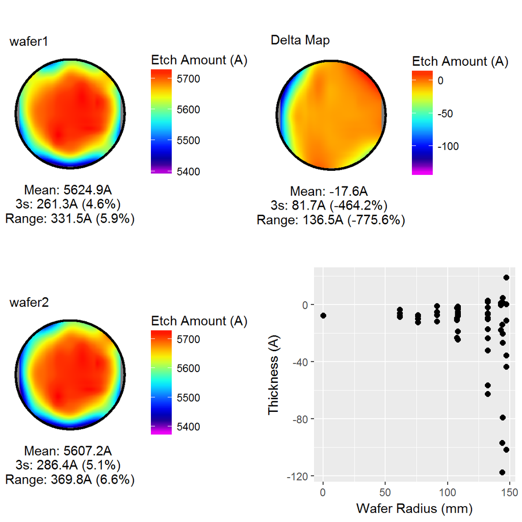

Wafer Side-by-side Comparison

```r
#read wafer collection data from tabulated csv file
wafer_collection <- system.file("extdata", "wafer_collection.csv", package="waferscopeR")
wafer.collection1 <- read.csv(wafer_collection)
#select slot1 from the collection and name z to "ThK"
wafer1 <- wafer.collection1[, 1:3]
wafer2<-wafer.collection1[, c(1,2,4)]
waferscopeR::compare_wafer(wafer1,wafer2, output="delta")
```

- output = “compare”, output two maps and side-by-side plot with boxplot and radial distribution

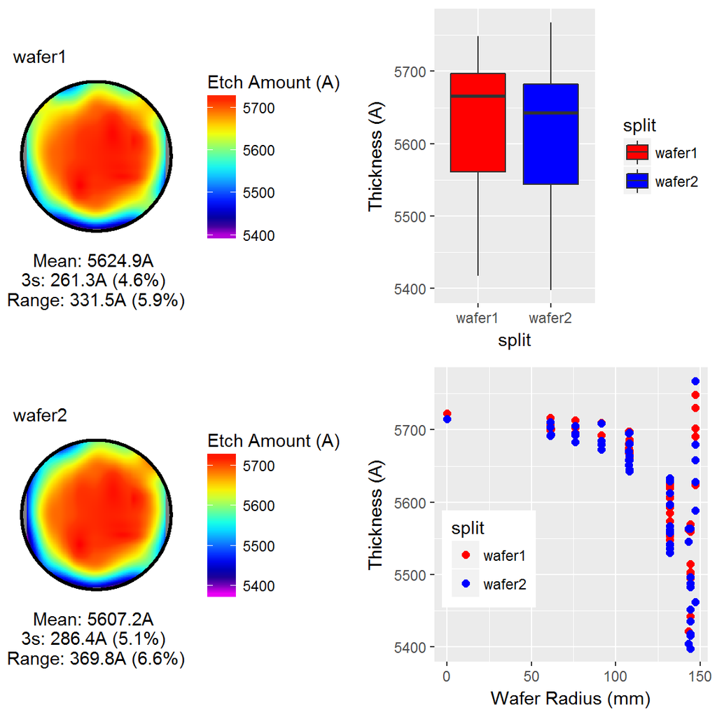

Wafer Side-by-side Comparison

```r
#read wafer collection data from tabulated csv file
wafer.collection1 <- read.csv(wafer_collection)
#select slot1 from the collection and name z to "ThK"
wafer1 <- wafer.collection1[, 1:3]
wafer2<-wafer.collection1[, c(1,2,4)]
waferscopeR::compare_wafer(wafer1,wafer2, output="compare")
```